# EDA 62 — Predisposing Variable Profile: Socio-demographics

Andersen Behavioral Model — Predisposing Domain

Author

Analysis Team

Published

May 22, 2026

# Mission

This EDA profiles the 13 predisposing variables (socio-demographic background) from the Andersen Behavioral Model framework. These represent immutable or slowly-changing characteristics that predispose individuals toward or away from health service use and, by extension, work absence.

**Research Questions:**

1. What is the weighted distribution of each predisposing variable in the employed population?
2. How does each predisposing variable relate to the primary outcome (`days_absent_total`) — mean days, median days, and zero-proportion?
3. What is the missing-data pattern across the 13 predisposing variables?
4. What demographic interactions exist — age×sex, education×immigration cross-tabs?

Following the dual-file development pattern, all analytical code lives in `analysis/eda-62/eda-62.R`. This document sources those chunks for presentation.

# Definition of Terms

**Predisposing factors**: In the Andersen Behavioral Model, these are characteristics that exist prior to the onset of illness — demographics (age, sex), social structure (education, marital status, immigration), and beliefs. They predispose individuals to differential health service use.

**`days_absent_total`**: Primary outcome. Row-wise sum of all 8 LOP component variables, representing total workdays missed in the past 3 months due to health reasons.

# Environment

> Reviews the components of the working environment. Non-technical readers may skip this section.

**Packages used in the current report**

```r
library(magrittr)
library(ggplot2)
library(forcats)
library(stringr)
library(dplyr)
library(tidyr)
library(scales)
library(fs)
requireNamespace("arrow")
```

**Collection of custom functions used in current repository**

```r
base::source("./scripts/common-functions.R")
base::source("./scripts/operational-functions.R")
if (file.exists("./scripts/graphing/graph-presets.R")) {
  base::source("./scripts/graphing/graph-presets.R")
}
```

**Values used throughout the report**

```r
local_root    <- "./analysis/eda-62/"
local_data    <- paste0(local_root, "data-local/")
prints_folder <- paste0(local_root, "prints/")
data_private_derived <- "./data-private/derived/eda-62/"

if (!fs::dir_exists(local_data))           fs::dir_create(local_data)
if (!fs::dir_exists(prints_folder))        fs::dir_create(prints_folder)
if (!fs::dir_exists(data_private_derived)) fs::dir_create(data_private_derived)

path_cchs2_parquet  <- "./data-private/derived/cchs-2-tables"
path_analytical_pq  <- file.path(path_cchs2_parquet, "cchs_analytic.parquet")
weight_col          <- "wts_m_pooled"

# The 13 predisposing variables (socio-demographic factors).
# `dhhgl12` and `home_ownership` added 2026-08-01. `dhhgl12` is redundant for
# modelling (it is the logical OR of the two flags above it) but is a legitimate
# descriptive marginal; `home_ownership` satisfies the Section 2.2 homeownership
# requirement previously believed to have no PUMF equivalent.
predisposing_vars <- c(
  "age_group_3", "dhhgage", "sex", "marital_status", "household_size",
  "dhhgle5", "dhhg611", "dhhgl12", "education", "immigration_status",
  "visible_minority", "home_ownership", "living_arrangements"
)

# Human-readable labels for display
predisposing_labels <- c(
  "age_group_3"         = "Age group (3 categories)",
  "dhhgage"             = "Age group (detailed)",
  "sex"                 = "Sex",
  "marital_status"      = "Marital status",
  "household_size"      = "Household size",
  "dhhgle5"             = "Child aged 0-5 in household",
  "dhhg611"             = "Child aged 6-11 in household",
  "dhhgl12"             = "Child under 12 in household",
  "education"           = "Education level",
  "immigration_status"  = "Immigration status",
  "visible_minority"    = "Visible minority",
  "home_ownership"      = "Home ownership",
  "living_arrangements" = "Living arrangements"
)
```

**Custom functions defined for use in this report**

```r
# No analysis-specific helpers required at this stage.
```

# Data

**Load data from Ellis parquet outputs**

```r
if (!file.exists(path_analytical_pq)) {
  stop("Missing required file: ", path_analytical_pq, call. = FALSE)
}

ds0 <- arrow::read_parquet(path_analytical_pq)

required_cols <- c(
  weight_col, "days_absent_total", "days_absent_chronic",
  "cchs_cycle", "cchs_cycle_f",
  predisposing_vars
)
missing_required <- setdiff(required_cols, names(ds0))
if (length(missing_required) > 0) {
  stop("Missing required columns in cchs_analytic.parquet: ",
       paste(missing_required, collapse = ", "), call. = FALSE)
}

cat(sprintf("Loaded analytical data: %s rows, %s columns\n",
            format(nrow(ds0), big.mark = ","),
            format(ncol(ds0), big.mark = ",")))
```

```
Loaded analytical data: 63,843 rows, 70 columns
```

## Data Context

For complete data documentation, see the Data Primer.

**Tables and variables used in this analysis**

```r
data_context_tables <- tibble::tibble(
  source_table = "cchs_analytic.parquet",
  location     = path_analytical_pq,
  rows         = nrow(ds0),
  columns      = ncol(ds0),
  usage        = paste(
    length(predisposing_vars), "predisposing socio-demographic variables,",
    "primary outcome days_absent_total, survey weight wts_m_pooled"
  )
)
print(data_context_tables)
```

```
# A tibble: 1 × 5
  source_table          location                                                  rows columns usage
  <chr>                 <chr>                                                    <int>   <int> <chr>
1 cchs_analytic.parquet ./data-private/derived/cchs-2-tables/cchs_analytic.parq… 63843      70 13 p…
```

**Representative individual**

```r
data_context_person <- ds0 %>%
  select(cchs_cycle_f, !!weight_col, days_absent_total, all_of(predisposing_vars)) %>%
  slice_head(n = 2)
print(data_context_person)
```

```
# A tibble: 2 × 16
  cchs_cycle_f wts_m_pooled days_absent_total age_group_3 dhhgage sex    marital_status
  <fct>               <dbl>             <dbl> <fct>         <dbl> <fct>  <fct>
1 2010-2011            147.                 0 15-24             4 Female Single / Never married
2 2010-2011            372.                 1 25-54             8 Female Common-law
# ℹ 9 more variables: household_size <ord>, dhhgle5 <dbl>, dhhg611 <dbl>, dhhgl12 <dbl>,
#   education <fct>, immigration_status <fct>, visible_minority <fct>, home_ownership <fct>,
#   living_arrangements <fct>
```

**Level counts for predisposing variables**

```r
# Level counts for each predisposing variable
data_context_distributions <- purrr::map_dfr(predisposing_vars, function(v) {
  tbl <- ds0 %>%
    count(value = as.character(.data[[v]])) %>%
    mutate(variable = v, label = predisposing_labels[v]) %>%
    arrange(desc(n))
  tbl
})
print(data_context_distributions, n = 40)
```

```
# A tibble: 60 × 4
   value                              n variable       label
   <chr>                          <int> <chr>          <chr>
 1 25-54                          37101 age_group_3    Age group (3 categories)
 2 55-75                          17080 age_group_3    Age group (3 categories)
 3 15-24                           9662 age_group_3    Age group (3 categories)
 4 11                              7760 dhhgage        Age group (detailed)
 5 10                              7459 dhhgage        Age group (detailed)
 6 7                               6348 dhhgage        Age group (detailed)
 7 8                               6290 dhhgage        Age group (detailed)
 8 5                               5886 dhhgage        Age group (detailed)
 9 9                               5562 dhhgage        Age group (detailed)
10 6                               5556 dhhgage        Age group (detailed)
11 12                              5543 dhhgage        Age group (detailed)
12 4                               5077 dhhgage        Age group (detailed)
```

[output cut: 29 more lines]

**Ensure factor types for categorical variables**

```r
# Ensure factor types for categorical variables
ds1 <- ds0 %>%
  select(
    cchs_cycle, cchs_cycle_f, !!weight_col,
    days_absent_total, days_absent_chronic,
    all_of(predisposing_vars)
  ) %>%
  mutate(across(
    all_of(predisposing_vars[!predisposing_vars %in%
                              c("household_size", "dhhgle5", "dhhg611", "dhhgl12")]),
    ~ as.factor(.x)
  ))
```

**Data overview**

```r
cat(sprintf("Working dataset: %s rows, %s columns\n",
            format(nrow(ds1), big.mark = ","), ncol(ds1)))
```

```
Working dataset: 63,843 rows, 18 columns
```

**Data overview**

```r
cat("Variable types:\n")
```

```
Variable types:
```

**Data overview**

```r
purrr::walk(predisposing_vars, function(v) {
  cat(sprintf("  %-22s %s (levels: %d)\n", v, class(ds1[[v]])[1],
              length(unique(ds1[[v]]))))
})
```

```
  age_group_3            factor (levels: 3)
  dhhgage                factor (levels: 14)
  sex                    factor (levels: 2)
  marital_status         factor (levels: 5)
  household_size         ordered (levels: 6)
  dhhgle5                numeric (levels: 2)
  dhhg611                numeric (levels: 2)
  dhhgl12                numeric (levels: 2)
  education              factor (levels: 5)
  immigration_status     factor (levels: 4)
  visible_minority       factor (levels: 3)
  home_ownership         factor (levels: 3)
  living_arrangements    factor (levels: 9)
```

**Data overview**

```r
# ==============================================================================
# G1 FAMILY — Variable Distributions
# Research question: What is the weighted distribution of each predisposing variable?
# g1  : unweighted frequency bar chart (select key variables)
# g11 : weighted frequency bar chart
# g12 : weighted distribution stratified by CCHS cycle
# ==============================================================================
```

# Analysis

## Graph Family G1: Variable Distributions

**Prepare distribution summaries**

```r
# Focus on the key categorical variables for bar chart display
g1_vars <- c("age_group_3", "sex", "marital_status", "education",
             "immigration_status", "visible_minority", "home_ownership",
             "living_arrangements")

g1_data <- purrr::map_dfr(g1_vars, function(v) {
  ds1 %>%
    filter(!is.na(.data[[v]])) %>%
    group_by(level = as.character(.data[[v]])) %>%
    summarise(
      n              = n(),
      pct_unweighted = n() / nrow(ds1) * 100,
      pct_weighted   = sum(.data[[weight_col]]) / sum(ds1[[weight_col]]) * 100,
      .groups = "drop"
    ) %>%
    mutate(variable = v, label = predisposing_labels[v])
})
```

**Unweighted distribution of predisposing variables**

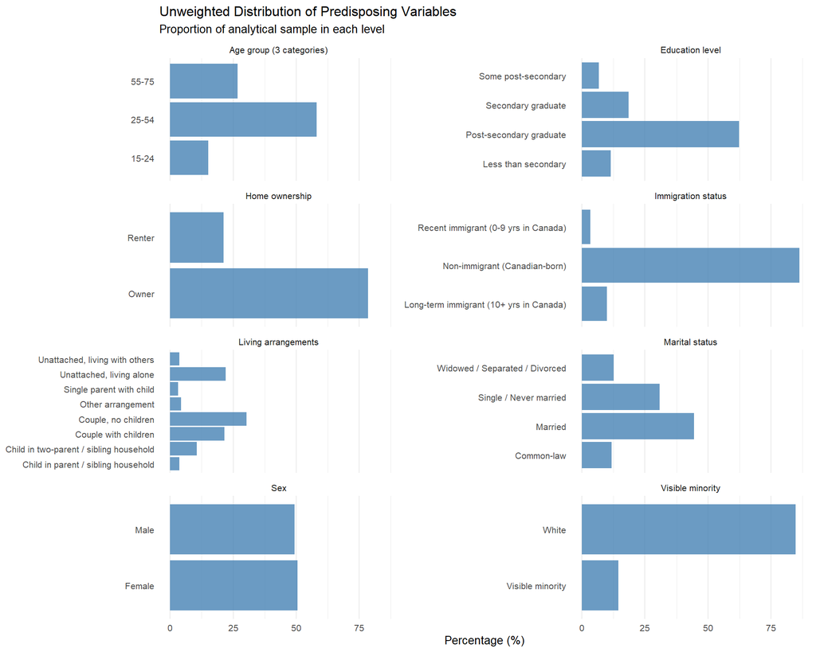

Unweighted frequency distribution by variable level

```r
g1_distribution <- g1_data %>%
  ggplot(aes(x = pct_unweighted, y = level)) +
  geom_col(fill = "#4682B4", alpha = 0.8) +
  facet_wrap(~ label, scales = "free_y", ncol = 2) +
  labs(
    title    = "Unweighted Distribution of Predisposing Variables",
    subtitle = "Proportion of analytical sample in each level",
    x = "Percentage (%)",
    y = NULL
  ) +
  theme_minimal(base_size = 10) +
  theme(panel.grid.major.y = element_blank())
print(g1_distribution)
```

**Unweighted distribution of predisposing variables**

```r
ggsave(paste0(prints_folder, "g1_distribution.png"),
       g1_distribution, width = 10, height = 8, dpi = 300)
```

**Weighted distribution of predisposing variables**

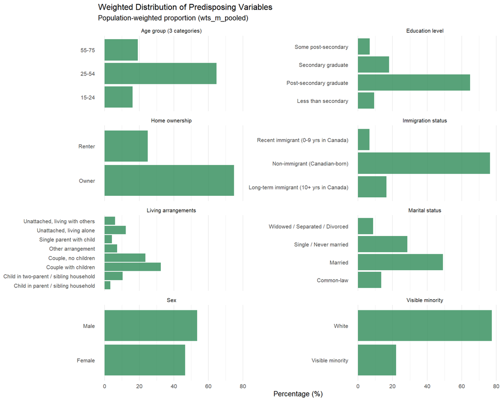

Population-weighted distribution using wts_m_pooled

```r
g11_weighted <- g1_data %>%
  ggplot(aes(x = pct_weighted, y = level)) +
  geom_col(fill = "#2E8B57", alpha = 0.8) +
  facet_wrap(~ label, scales = "free_y", ncol = 2) +
  labs(
    title    = "Weighted Distribution of Predisposing Variables",
    subtitle = "Population-weighted proportion (wts_m_pooled)",
    x = "Percentage (%)",
    y = NULL
  ) +
  theme_minimal(base_size = 10) +
  theme(panel.grid.major.y = element_blank())
print(g11_weighted)
```

**Weighted distribution of predisposing variables**

```r
ggsave(paste0(prints_folder, "g11_weighted.png"),
       g11_weighted, width = 10, height = 8, dpi = 300)
```

**Weighted distribution by CCHS cycle**

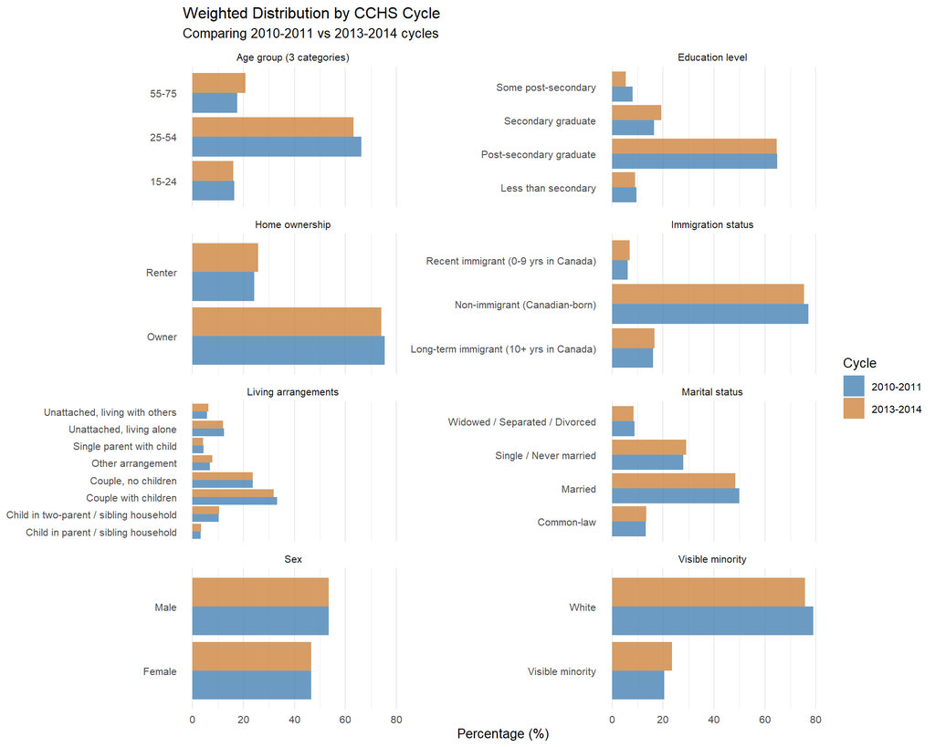

Distribution comparison between 2010-2011 and 2013-2014 cycles

```r
g12_data <- purrr::map_dfr(g1_vars, function(v) {
  ds1 %>%
    filter(!is.na(.data[[v]])) %>%
    group_by(level = as.character(.data[[v]]), cchs_cycle_f) %>%
    summarise(
      pct_weighted = sum(.data[[weight_col]]) /
        sum(ds1[[weight_col]][ds1$cchs_cycle_f == unique(cchs_cycle_f)]) * 100,
      .groups = "drop"
    ) %>%
    mutate(variable = v, label = predisposing_labels[v])
})

g12_by_cycle <- g12_data %>%
  ggplot(aes(x = pct_weighted, y = level, fill = cchs_cycle_f)) +
  geom_col(position = "dodge", alpha = 0.8) +
  facet_wrap(~ label, scales = "free_y", ncol = 2) +
  scale_fill_manual(values = c("2010-2011" = "#4682B4", "2013-2014" = "#CD853F")) +
  labs(
    title    = "Weighted Distribution by CCHS Cycle",
    subtitle = "Comparing 2010-2011 vs 2013-2014 cycles",
    x = "Percentage (%)",
    y = NULL,
    fill = "Cycle"
  ) +
  theme_minimal(base_size = 10) +
  theme(panel.grid.major.y = element_blank())
print(g12_by_cycle)
```

**Weighted distribution by CCHS cycle**

```r
ggsave(paste0(prints_folder, "g12_by_cycle.png"),
       g12_by_cycle, width = 10, height = 8, dpi = 300)


# ==============================================================================
# G2 FAMILY — Outcome Relationship
# Research question: How does each predisposing variable relate to days_absent_total?
# g2  : mean days absent by variable level (dot plot)
# g21 : median + IQR by variable level
# g22 : zero-proportion by variable level
# ==============================================================================
```

## Graph Family G2: Outcome Relationship

**Prepare outcome summaries by variable level**

```r
g2_data <- purrr::map_dfr(g1_vars, function(v) {
  ds1 %>%
    filter(!is.na(.data[[v]])) %>%
    group_by(level = as.character(.data[[v]])) %>%
    summarise(
      n           = n(),
      mean_days   = weighted.mean(days_absent_total, w = .data[[weight_col]], na.rm = TRUE),
      median_days = median(days_absent_total, na.rm = TRUE),
      q25         = quantile(days_absent_total, 0.25, na.rm = TRUE),
      q75         = quantile(days_absent_total, 0.75, na.rm = TRUE),
      pct_zero    = weighted.mean(days_absent_total == 0, w = .data[[weight_col]], na.rm = TRUE) * 100,
      .groups = "drop"
    ) %>%
    mutate(variable = v, label = predisposing_labels[v])
})
```

**Mean days absent by predisposing variable level**

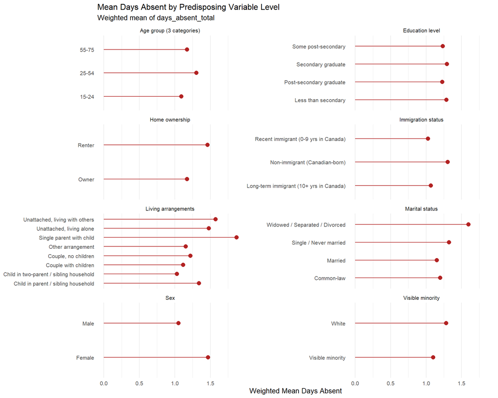

Weighted mean days absent by demographic level

```r
g2_mean_days <- g2_data %>%
  ggplot(aes(x = mean_days, y = level)) +
  geom_point(size = 2.5, color = "#B22222") +
  geom_segment(aes(xend = 0, yend = level), color = "#B22222", linewidth = 0.4) +
  facet_wrap(~ label, scales = "free_y", ncol = 2) +
  labs(
    title    = "Mean Days Absent by Predisposing Variable Level",
    subtitle = "Weighted mean of days_absent_total",
    x = "Weighted Mean Days Absent",
    y = NULL
  ) +
  theme_minimal(base_size = 10) +
  theme(panel.grid.major.y = element_blank())
print(g2_mean_days)
```

**Mean days absent by predisposing variable level**

```r
ggsave(paste0(prints_folder, "g2_mean_days.png"),
       g2_mean_days, width = 10, height = 8, dpi = 300)
```

**Median days absent (IQR) by variable level**

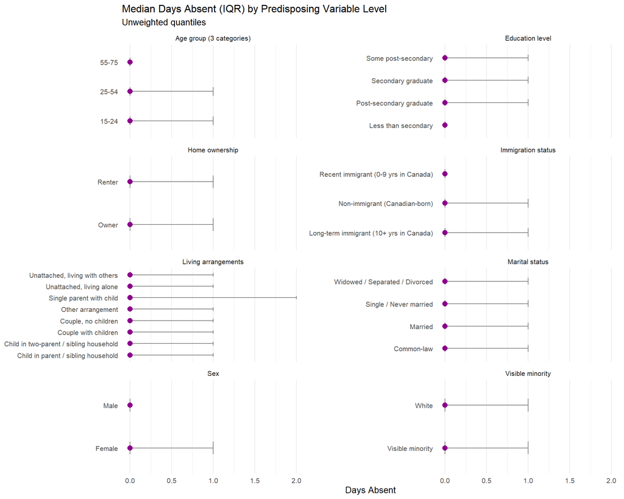

Median and interquartile range of days absent

```r
g21_median_iqr <- g2_data %>%
  ggplot(aes(y = level)) +
  geom_errorbarh(aes(xmin = q25, xmax = q75), height = 0.3, color = "grey50") +
  geom_point(aes(x = median_days), size = 2.5, color = "#8B008B") +
  facet_wrap(~ label, scales = "free_y", ncol = 2) +
  labs(
    title    = "Median Days Absent (IQR) by Predisposing Variable Level",
    subtitle = "Unweighted quantiles",
    x = "Days Absent",
    y = NULL
  ) +
  theme_minimal(base_size = 10) +
  theme(panel.grid.major.y = element_blank())
print(g21_median_iqr)
```

**Median days absent (IQR) by variable level**

```r
ggsave(paste0(prints_folder, "g21_median_iqr.png"),
       g21_median_iqr, width = 10, height = 8, dpi = 300)
```

**Zero-day proportion by variable level**

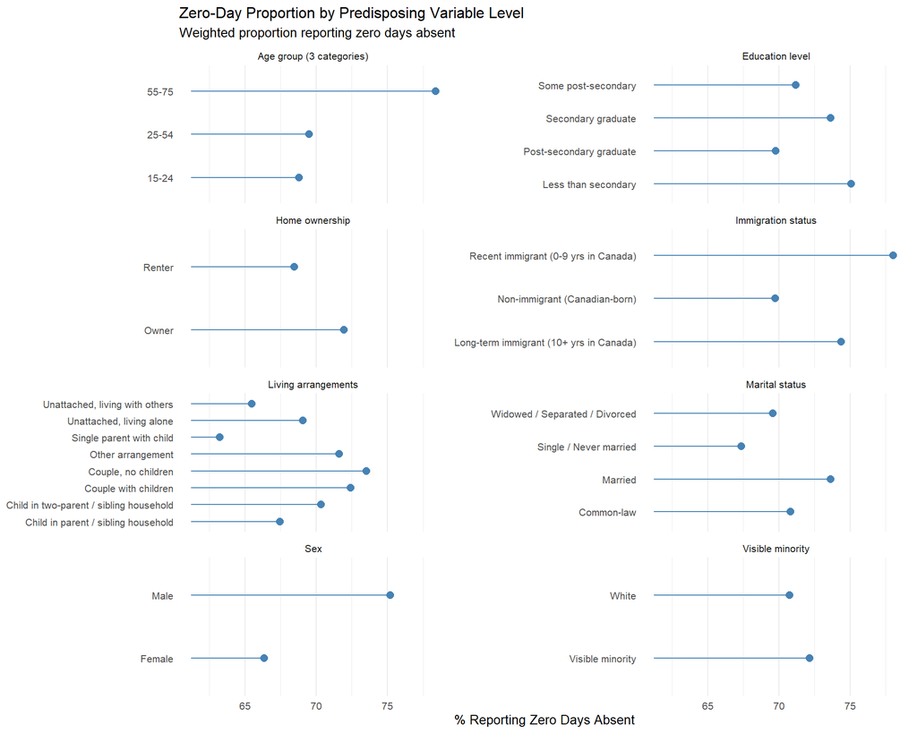

Proportion reporting zero days absent by demographic group

```r
g22_zero_prop <- g2_data %>%
  ggplot(aes(x = pct_zero, y = level)) +
  geom_point(size = 2.5, color = "#4682B4") +
  geom_segment(aes(xend = min(pct_zero) - 2, yend = level),
               color = "#4682B4", linewidth = 0.4) +
  facet_wrap(~ label, scales = "free_y", ncol = 2) +
  labs(
    title    = "Zero-Day Proportion by Predisposing Variable Level",
    subtitle = "Weighted proportion reporting zero days absent",
    x = "% Reporting Zero Days Absent",
    y = NULL
  ) +
  theme_minimal(base_size = 10) +
  theme(panel.grid.major.y = element_blank())
print(g22_zero_prop)
```

**Zero-day proportion by variable level**

```r
ggsave(paste0(prints_folder, "g22_zero_prop.png"),
       g22_zero_prop, width = 10, height = 8, dpi = 300)


# ==============================================================================
# G3 FAMILY — Missing Data Profile
# Research question: What is the missing-data pattern across predisposing variables?
# g3  : missingness bar chart
# g31 : missingness by cycle
# ==============================================================================
```

## Graph Family G3: Missing Data Profile

**Compute missingness statistics**

```r
g3_data <- ds0 %>%
  summarise(across(all_of(predisposing_vars), ~ sum(is.na(.x)))) %>%
  pivot_longer(everything(), names_to = "variable", values_to = "n_missing") %>%
  mutate(
    label       = predisposing_labels[variable],
    pct_missing = n_missing / nrow(ds0) * 100
  ) %>%
  arrange(desc(pct_missing))

g3_by_cycle <- ds0 %>%
  group_by(cchs_cycle_f) %>%
  summarise(across(all_of(predisposing_vars), ~ sum(is.na(.x)) / n() * 100)) %>%
  pivot_longer(-cchs_cycle_f, names_to = "variable", values_to = "pct_missing") %>%
  mutate(label = predisposing_labels[variable])
```

**Missingness profile across predisposing variables**

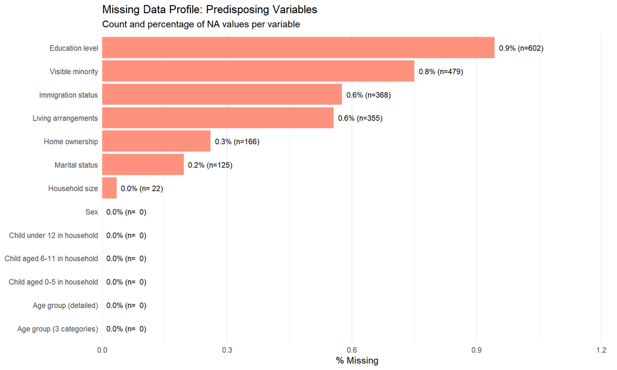

Percentage and count of missing values per variable

```r
g3_missing <- g3_data %>%
  ggplot(aes(x = pct_missing, y = fct_reorder(label, pct_missing))) +
  geom_col(fill = "#FF6347", alpha = 0.7) +
  geom_text(aes(label = sprintf("%.1f%% (n=%s)", pct_missing, format(n_missing, big.mark = ","))),
            hjust = -0.1, size = 3) +
  scale_x_continuous(expand = expansion(mult = c(0, 0.3))) +
  labs(
    title    = "Missing Data Profile: Predisposing Variables",
    subtitle = "Count and percentage of NA values per variable",
    x = "% Missing",
    y = NULL
  ) +
  theme_minimal(base_size = 11) +
  theme(panel.grid.major.y = element_blank())
print(g3_missing)
```

**Missingness profile across predisposing variables**

```r
ggsave(paste0(prints_folder, "g3_missing.png"),
       g3_missing, width = 8.5, height = 5.5, dpi = 300)
```

**Missingness by CCHS cycle**

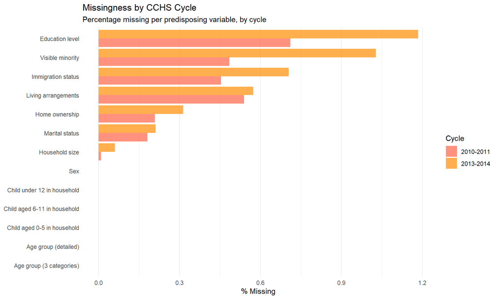

Missing data rates by survey cycle

```r
g31_missing_by_cycle <- g3_by_cycle %>%
  ggplot(aes(x = pct_missing, y = fct_reorder(label, pct_missing),
             fill = cchs_cycle_f)) +
  geom_col(position = "dodge", alpha = 0.7) +
  scale_fill_manual(values = c("2010-2011" = "#FF6347", "2013-2014" = "#FF8C00")) +
  labs(
    title    = "Missingness by CCHS Cycle",
    subtitle = "Percentage missing per predisposing variable, by cycle",
    x = "% Missing",
    y = NULL,
    fill = "Cycle"
  ) +
  theme_minimal(base_size = 11) +
  theme(panel.grid.major.y = element_blank())
print(g31_missing_by_cycle)
```

**Missingness by CCHS cycle**

```r
ggsave(paste0(prints_folder, "g31_missing_by_cycle.png"),
       g31_missing_by_cycle, width = 8.5, height = 5.5, dpi = 300)


# ==============================================================================
# G4 FAMILY — Demographic Interactions
# Research question: What demographic interactions exist (age×sex, education×immigration)?
# g4  : age × sex cross-tab (mean days absent)
# g41 : education × immigration cross-tab
# ==============================================================================
```

## Graph Family G4: Demographic Interactions

**Compute cross-tabulated outcome summaries**

```r
g4_age_sex <- ds1 %>%
  filter(!is.na(age_group_3), !is.na(sex)) %>%
  group_by(age_group_3, sex) %>%
  summarise(
    n         = n(),
    mean_days = weighted.mean(days_absent_total, w = .data[[weight_col]], na.rm = TRUE),
    pct_zero  = weighted.mean(days_absent_total == 0, w = .data[[weight_col]], na.rm = TRUE) * 100,
    .groups = "drop"
  )

g4_edu_imm <- ds1 %>%
  filter(!is.na(education), !is.na(immigration_status)) %>%
  group_by(education, immigration_status) %>%
  summarise(
    n         = n(),
    mean_days = weighted.mean(days_absent_total, w = .data[[weight_col]], na.rm = TRUE),
    pct_zero  = weighted.mean(days_absent_total == 0, w = .data[[weight_col]], na.rm = TRUE) * 100,
    .groups = "drop"
  )
```

**Age group × sex interaction**

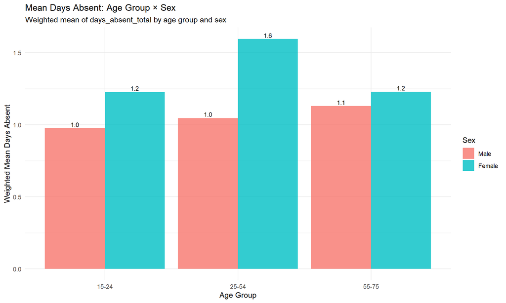

Mean days absent by age group and sex

```r
g4_age_sex_plot <- g4_age_sex %>%
  ggplot(aes(x = age_group_3, y = mean_days, fill = sex)) +
  geom_col(position = "dodge", alpha = 0.8) +
  geom_text(aes(label = sprintf("%.1f", mean_days)),
            position = position_dodge(width = 0.9), vjust = -0.3, size = 3) +
  labs(
    title    = "Mean Days Absent: Age Group × Sex",
    subtitle = "Weighted mean of days_absent_total by age group and sex",
    x = "Age Group",
    y = "Weighted Mean Days Absent",
    fill = "Sex"
  ) +
  theme_minimal(base_size = 11)
print(g4_age_sex_plot)
```

**Age group × sex interaction**

```r
ggsave(paste0(prints_folder, "g4_age_sex.png"),
       g4_age_sex_plot, width = 8.5, height = 5.5, dpi = 300)
```

**Education × immigration status interaction**

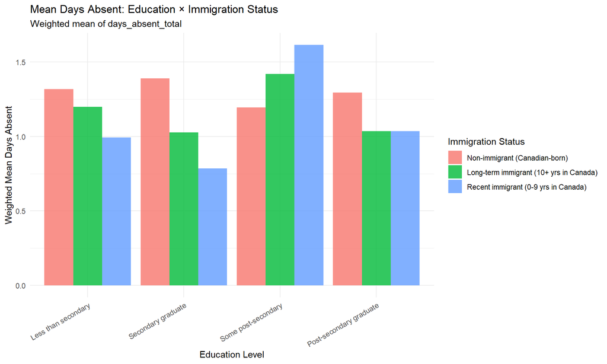

Mean days absent by education level and immigration status

```r
g41_edu_imm_plot <- g4_edu_imm %>%
  ggplot(aes(x = education, y = mean_days, fill = immigration_status)) +
  geom_col(position = "dodge", alpha = 0.8) +
  labs(
    title    = "Mean Days Absent: Education × Immigration Status",
    subtitle = "Weighted mean of days_absent_total",
    x = "Education Level",
    y = "Weighted Mean Days Absent",
    fill = "Immigration Status"
  ) +
  theme_minimal(base_size = 11) +
  theme(axis.text.x = element_text(angle = 30, hjust = 1))
print(g41_edu_imm_plot)
```

**Education × immigration status interaction**

```r
ggsave(paste0(prints_folder, "g41_edu_imm.png"),
       g41_edu_imm_plot, width = 8.5, height = 5.5, dpi = 300)

# nolint end
```